# Project: Investigating a Movie Dataset [TMDB Movies]

### Question 2: what genres do viewers like

```python
# brief of genre
pd.DataFrame(df['genres'].describe())
```

|  | genres |
| --- | --- |
| count | 3805 |
| unique | 19 |
| top | Drama |
| freq | 876 |

| genres | popularity |
| --- | --- |
| TV Movie | 0.273628 |
| Documentary | 0.354309 |
| Horror | 0.860527 |
| Music | 0.914098 |
| Comedy | 0.924824 |
| Drama | 0.938702 |
| Crime | 1.074895 |
| Mystery | 1.133780 |
| Thriller | 1.171430 |
| Western | 1.193918 |
| Romance | 1.386988 |
| History | 1.442235 |
| Action | 1.451147 |
| Fantasy | 1.595149 |
| Family | 1.609295 |
| War | 1.658497 |
| Animation | 1.739861 |
| Adventure | 1.915165 |
| Science Fiction | 1.931437 |

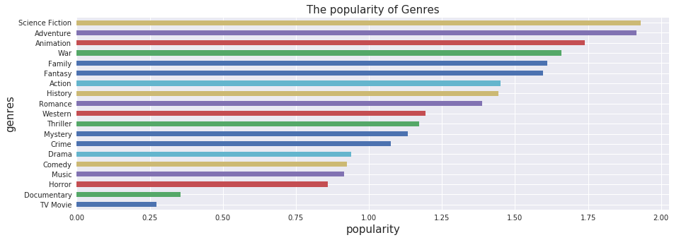

```python
#Plotting genres against popularity
pop_genres= df.groupby('genres')['popularity'].mean().sort_values(ascending=True)
pop_genres.plot(kind='barh',figsize =(15,5))
plt.xlabel('popularity', fontsize=15)
plt.ylabel('genres', fontsize=15)
plt.title('The popularity of Genres', fontsize=15)
pd.DataFrame(df.groupby('genres')['popularity'].mean().sort_values(ascending=True))
```

> The chart above shows that science fiction is the most popular among viewers.

| genres | vote_count |
| --- | --- |
| Action | 498346 |
| Drama | 337362 |
| Adventure | 309220 |
| Comedy | 253762 |
| Science Fiction | 104037 |
| Animation | 94492 |
| Horror | 85256 |
| Thriller | 81692 |
| Fantasy | 76900 |
| Crime | 76069 |
| Romance | 33849 |
| Family | 26712 |
| Mystery | 15606 |
| War | 14054 |
| History | 9425 |
| Western | 6814 |
| Music | 6813 |
| Documentary | 2031 |
| TV Movie | 35 |

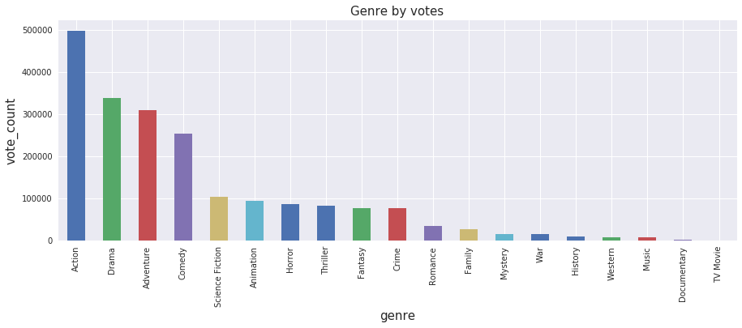

```python
#Plotting genres against vote_count
pop_genres= df.groupby('genres')['vote_count'].sum().sort_values(ascending=False)
pop_genres.plot(kind='bar',figsize =(15,5))
plt.xlabel('genre', fontsize=15)
plt.ylabel('vote_count', fontsize=15)
plt.title('Genre by votes', fontsize=15)
pd.DataFrame(df.groupby('genres')['vote_count'].sum().sort_values(ascending=False))
```

> The chart shows that action movies are viewed more by votes

| genres | vote_average |
| --- | --- |
| Drama | 5645.7 |
| Comedy | 4662.3 |
| Action | 4104.9 |
| Adventure | 1949.1 |
| Horror | 1566.2 |
| Crime | 1104.7 |
| Thriller | 958.9 |
| Fantasy | 664.0 |
| Animation | 643.9 |
| Science Fiction | 612.0 |
| Romance | 418.9 |
| Family | 244.0 |
| Mystery | 220.9 |
| Music | 179.6 |
| Documentary | 155.6 |
| War | 129.6 |
| History | 110.4 |
| Western | 102.7 |
| TV Movie | 5.6 |

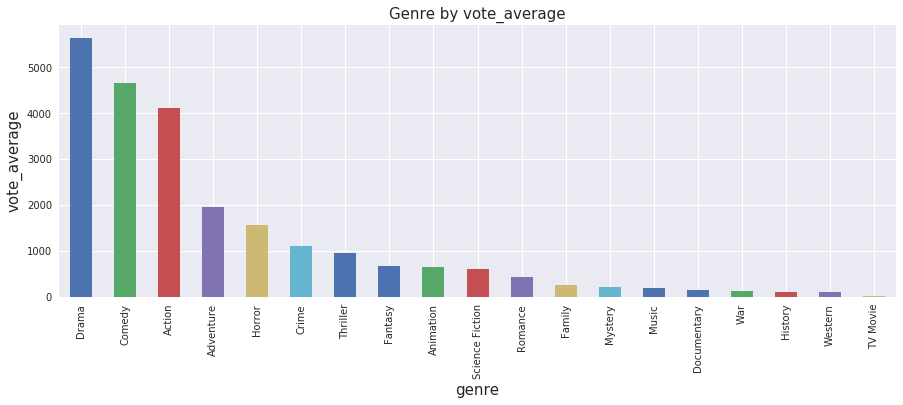

```python
#Plotting genres against vote_average
pop_genres= df.groupby('genres')['vote_average'].sum().sort_values(ascending=False)
pop_genres.plot(kind='bar',figsize =(15,5))
plt.xlabel('genre', fontsize=15)
plt.ylabel('vote_average', fontsize=15)
plt.title('Genre by vote_average', fontsize=15)
pd.DataFrame(df.groupby('genres')['vote_average'].sum().sort_values(ascending=False))
```

## Limitations

- After investigating it was discovered that the movies were 10,866 instead of 10,000, and along the line there were missing values,duplicates and so much '0' in the data.
- There were entries in the rows separated with a delimiter '|' which resulted in picking the main entry from the rows which will eventually give a less accurate result.

## References

- Stackoverflow
- Udacity Lecture note

```python
from subprocess import call
call(['python', '-m', 'nbconvert', 'Investigate_a_Dataset.ipynb'])
```

```
0
```